# PCFL 2021: Week 10 wrap-up

We’re now over halfway through our regular season! Playoffs start in seven weeks.

### Last week’s games

| Away | Away points | Home | Home points | Predicted result |
| --- | --- | --- | --- | --- |
| Athens Team Sasquatch | 132.49 | Georgia Peanuts | 84.05 | Georgia Peanuts (+1.27) |
| Southern Sharks | 126.52 | KC Gophers | 66.74 | Southern Sharks (+23.12) |
| Jumpin’ Jaheims | 57.00 | The G.O.A.T. | 118.04 | Jumpin’ Jaheims (+21.86) |
| The Sophomores TSoph | 81.44 | Middle Earth Hangry Hobbits | 72.72 | The Sophomores TSoph (+15.75) |
| Pigskin on the Gridiron | 101.04 | Captain Clairvoyant | 109.40 | Pigskin on the Gridiron (+2.39) |

#### Best performing players

Here’s last week’s **10 best performing players.**

| Player | Points | Team |
| --- | --- | --- |
| Patrick Mahomes | 36.24 | KC Gophers |
| Deebo Samuel | 28.80 | Athens Team Sasquatch |
| CeeDee Lamb | 26.55 | Athens Team Sasquatch |
| Dak Prescott | 26.34 | The G.O.A.T. |
| Stefon Diggs | 26.20 | Southern Sharks |
| Darrel Williams | 24.90 | Athens Team Sasquatch |
| Tyreek Hill | 24.00 | The Sophomores TSoph |
| Cowboys D/ST | 22.00 | Athens Team Sasquatch |
| Jonathan Taylor | 21.60 | Captain Clairvoyant |
| Christian McCaffrey | 21.10 | Southern Sharks |

It’s been an up and down season for Mahomes, but he was dominant this week. A good week for lots of receivers (Samuel, Lamb, Diggs, Hill). Good to see McCaffrey get back in the top 10 after time lost due to injury.

#### Best addition and top bench

There were 22 players added last week. Which was the **best new addition**?

| Date added | Name | Points | Team |
| --- | --- | --- | --- |
| 2021-11-10 | Jamal Agnew | 20.45 | Athens Team Sasquatch |
| 2021-11-14 | Mac Jones | 19.92 | Captain Clairvoyant |
| 2021-11-10 | D’Ernest Johnson | 19.20 | Athens Team Sasquatch |
| 2021-11-13 | Mark Ingram II | 18.80 | Middle Earth Hangry Hobbits |
| 2021-11-11 | Deonte Harris | 14.20 | Captain Clairvoyant |
| 2021-11-14 | Panthers D/ST | 14.00 | The G.O.A.T. |
| 2021-11-10 | Chris Boswell | 12.00 | Southern Sharks |
| 2021-11-11 | Elijah Moore | 11.90 | Georgia Peanuts |
| 2021-11-10 | Jordan Howard | 8.30 | Captain Clairvoyant |
| 2021-11-11 | Devonta Freeman | 7.30 | Middle Earth Hangry Hobbits |
| 2021-11-12 | Zach Ertz | 6.60 | KC Gophers |
| 2021-11-11 | J.D. McKissic | 5.90 | Jumpin’ Jaheims |
| 2021-11-10 | Titans D/ST | 5.00 | Georgia Peanuts |
| 2021-11-12 | Baker Mayfield | 4.92 | KC Gophers |
| 2021-11-11 | Jamison Crowder | 3.50 | Georgia Peanuts |
| 2021-11-10 | Daniel Carlson | 2.00 | Middle Earth Hangry Hobbits |
| 2021-11-10 | Broncos D/ST | 2.00 | Middle Earth Hangry Hobbits |
| 2021-11-14 | T.Y. Hilton | 1.00 | Captain Clairvoyant |
| 2021-11-11 | Rams D/ST | 1.00 | Jumpin’ Jaheims |
| 2021-11-10 | Matt Ryan | 0.68 | Pigskin on the Gridiron |
| 2021-11-11 | Chris Carson | 0.00 | Georgia Peanuts |
| 2021-11-11 | Rob Gronkowski | 0.00 | Jumpin’ Jaheims |

Jamal Agnew is not a name I was familiar with prior to last week, but the Jaguars WR had an impressive week. Mac Jones might be the first rookie QB to come out near the top of the list. As someone with two Cleveland RBs out with injury, I will forego commenting on D’Ernest Johnson’s performance.

Who won the **best scoring bench** award last week?

| Team | Points |
| --- | --- |
| Athens Team Sasquatch | 73.95 |
| Captain Clairvoyant | 64.92 |
| Pigskin on the Gridiron | 63.37 |
| Southern Sharks | 58.91 |
| Middle Earth Hangry Hobbits | 58.72 |
| Jumpin’ Jaheims | 53.02 |
| The Sophomores TSoph | 48.84 |
| KC Gophers | 39.02 |
| Georgia Peanuts | 32.42 |
| The G.O.A.T. | 25.04 |

Robbie not only led the league with his starters, but also his bench!

Who has the most bench points for the *season*? Here’s the current standings:

| Team name | Total bench points |
| --- | --- |
| Southern Sharks | 849.63 |
| Middle Earth Hangry Hobbits | 765.95 |
| Athens Team Sasquatch | 745.18 |
| The Sophomores TSoph | 712.80 |
| Pigskin on the Gridiron | 678.32 |
| Jumpin’ Jaheims | 612.38 |
| KC Gophers | 588.50 |
| Captain Clairvoyant | 579.60 |
| The G.O.A.T. | 512.19 |
| Georgia Peanuts | 506.11 |

Sarah came in 4th this week, but she’s still in first place by 84 points. I’m still in last place.

### League standings and season stats

Here’s a look at the current standings.

| Team | Division | W | L | Points scored | Points allowed | Points rank | Playoff rank |
| --- | --- | --- | --- | --- | --- | --- | --- |
| The Sophomores TSoph | Hot Dish | 8 | 2 | 1185.44 | 1049.36 | 2 | 1 |
| Captain Clairvoyant | Grits | 7 | 3 | 1139.20 | 1037.63 | 4 | 2 |
| Athens Team Sasquatch | Grits | 6 | 4 | 1205.79 | 1167.67 | 1 | 3 |
| Pigskin on the Gridiron | Grits | 6 | 4 | 1156.29 | 1113.52 | 3 | 4 |
| Middle Earth Hangry Hobbits | Hot Dish | 5 | 5 | 1111.10 | 1021.56 | 6 | 5 |
| Georgia Peanuts | Hot Dish | 5 | 5 | 1068.29 | 1089.80 | 7 | 6 |
| Southern Sharks | Hot Dish | 4 | 6 | 1114.56 | 1112.14 | 5 | 7 |
| Jumpin’ Jaheims | Grits | 4 | 6 | 1031.53 | 1156.46 | 8 | 8 |
| The G.O.A.T. | Grits | 3 | 7 | 934.36 | 1011.97 | 9 | 9 |
| KC Gophers | Hot Dish | 2 | 8 | 929.50 | 1115.95 | 10 | 10 |

Here’s a list of the **top five scoring performances** so far this season.

| Team | Week | Points scored | Result |
| --- | --- | --- | --- |
| Georgia Peanuts | 5 | 158.97 | W |
| The Sophomores TSoph | 4 | 158.62 | W |
| Athens Team Sasquatch | 5 | 149.80 | W |
| The G.O.A.T. | 4 | 149.52 | W |
| KC Gophers | 1 | 149.28 | W |

No new entries this week. Bye weeks are making this section a little stale!

### Here’s a look at the **points trendline** for each team.

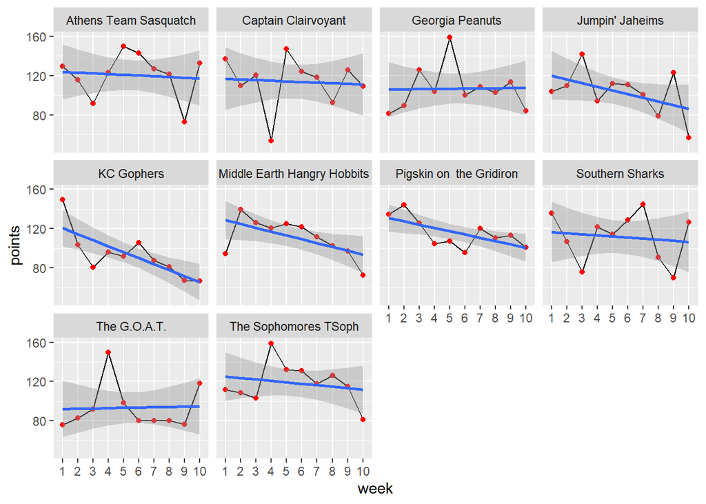

Nice rebound for Team Sasquatch and the Southern Sharks this week. Jacob’s good week also stands out. Many of us not trending in the right direction, though.

### If the season ended today…

Our playoff teams would be Erin/Trav, Brian, Robbie and Richard (the same as last week). Our last place finisher is now Christine–Jacob climbs up to 9th place. On the edge, the Peanuts and Hobbits lose out on the last playoff spot by one loss, and both Evan and Sarah are two back.

### Next week’s preview

| Away team | Last 3 wks avg (away) | Home team | Last 3 wks avg (home) | Line |
| --- | --- | --- | --- | --- |
| Jumpin’ Jaheims | 86.33 | KC Gophers | 71.73 | Jumpin’ Jaheims (+14.6) |
| Middle Earth Hangry Hobbits | 90.69 | Georgia Peanuts | 99.99 | Georgia Peanuts (+9.3) |
| Athens Team Sasquatch | 108.85 | Pigskin on the Gridiron | 108.31 | Athens Team Sasquatch (+0.54) |
| The Sophomores TSoph | 107.35 | Southern Sharks | 95.74 | The Sophomores TSoph (+11.61) |
| The G.O.A.T. | 91.59 | Captain Clairvoyant | 109.30 | Captain Clairvoyant (+17.71) |

Another top matchup with Richard this week, facing off against the blazing hot Team Sasquatch. Stay clear of the Sophomores vs. Sharks game this week, as that could get dangerous. I face off against Scott with both of us fighting for a playoff spot. Evan also battles Christine, and Jacob tries to keep the wins coming against Brian.

Good luck, y’all! (And remember to check your byes!)